# 2022 Regionals Predictive Modeling

Emily Murphy, Dwight Wynne

6/14/2022

The statistics from the 2015-2018 seasons were merged with the data from the 2015-2018 Regional games to create one set of data that contains each Regional game for a particular year, who the host, home, and visiting teams were, who won each game, and each team’s statistics for that season.

A model was built that uses the eight different statistics that were shown to be most important when predicting which team wins a game. The model also takes the regional host into account and adjusts for conference.

The model resulted in a 75% accuracy when tested on 2022 games, meaning it accurately predicted the outcome of approximately 75% of the 2022 Regional games. Now, using this model, the chances of a home team winning a game given both the home and visiting team statistics can be predicted with about 75% confidence.

Given CSUF’s 2022 statistics, the model can be used to estimate the chances CSUF had of winning each game in the Arizona St. regional. This can be compared to the chances CSUF would have had according to the model if they had reached what the estimated goals would have been for each statistic this season. These estimated goals were calculated by averaging the 2021 WCWS per game statistics, and then averaging those with CSUF’s 2021 per game statistics to obtain a goal for each stat. Again, each statistic was changed to be per game rather than the total to make for easier comparison.

Figure 1 below shows CSUF’s actual 2022 data in the eight statistics that were considered to have the most influence on who wins a game, as well as what the estimated goals were for this season in the same stats. Note that all statistics shown are standardized per game.

Predictive Model Statistics

Figure 1: A table showing the statistics the model determined were most effective in predicting which team wins. Includes CSUF's actual season values in these statistics as well as the estimated goals for each.

| Input | Batting Average | Runs Allowed | Singles | Doubles | Triples | Home Runs | Slugging Percentage | Double Plays |
| --- | --- | --- | --- | --- | --- | --- | --- | --- |
| CSUF Actual | 0.31 | 3.95 | 6.14 | 1.39 | 0.09 | 0.7 | 0.44 | 0.29 |
| Estimated goals | 0.32 | 2.63 | 5.30 | 1.46 | 0.14 | 1.3 | 0.54 | 0.27 |

Figures 2.1-2.3 are graphs comparing CSUF’s chances of winning according to the model using CSUF’s 2022 stats to what their chances would have been had they achieved the estimated goals. The horizontal axis indicates what was input into the model. The vertical axis represents the probability of CSUF winning against the corresponding team.

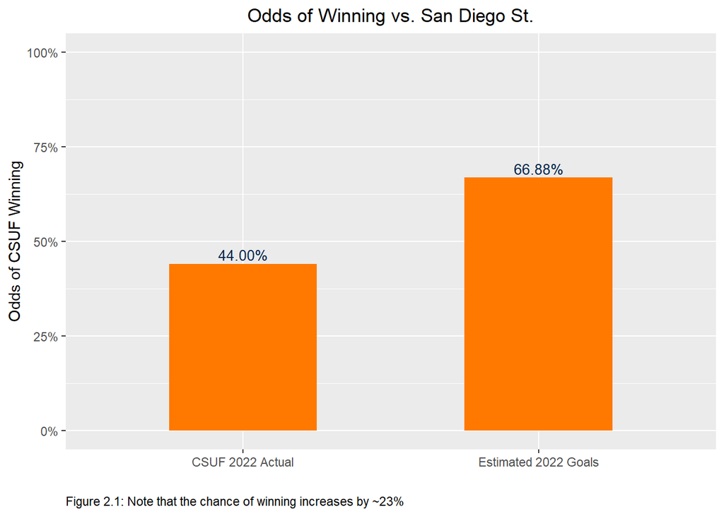

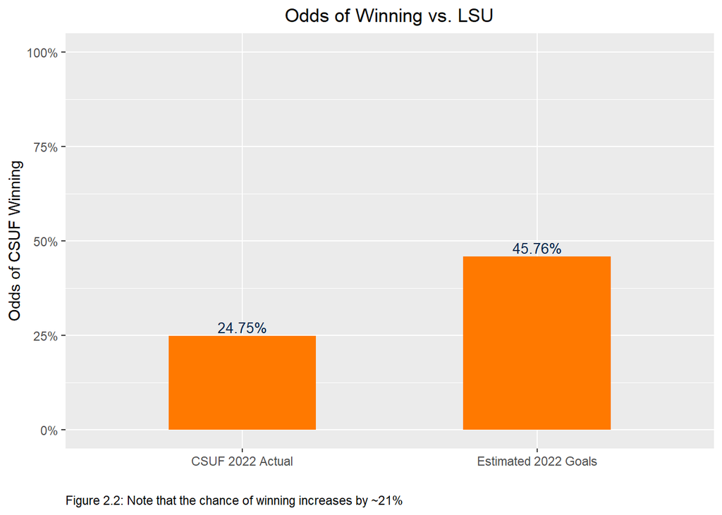

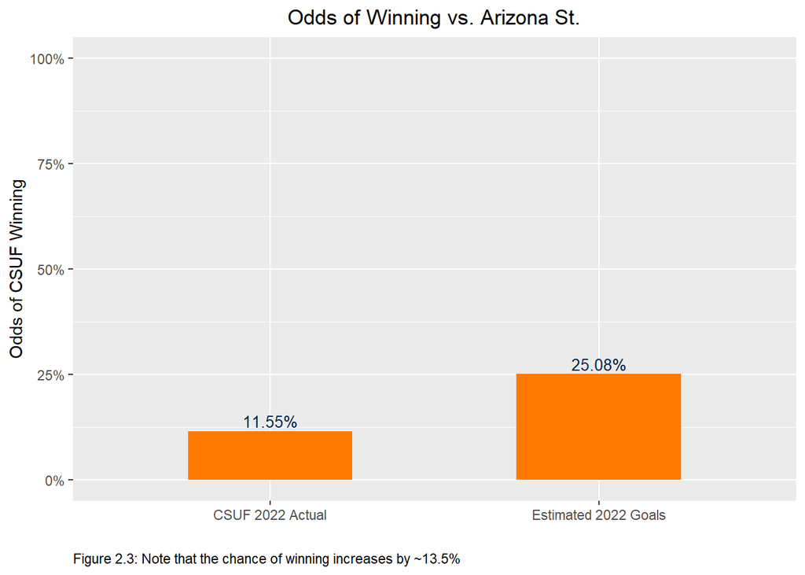

According to the model, CSUF’s statistics for the 2022 season gave them approximately a 44% and 25% chance of beating San Diego St. and LSU respectively. If CSUF had achieved the estimated goals for the season, the model predicts that their chances of winning against the same teams would have increased to 67% and 46%.

Against Arizona St., however, achieving the estimated goals for the season only would have resulted in about a 25% chance of winning.

The model can be used to estimate the effect of improvement in one statistic on the overall chances of winning against a given team. For example, CSUF allowed about 4 runs per game. If pitching is something the team is planning on working on, then we can use the model to estimate the chances CSUF would have of winning against teams with similar stats to those CSUF faced in the regional by changing the number of runs they allow per game from 4 to 3 and keeping every other statistic the same.

Figure 3 below is the same table as figure 1, but includes a row that outlines the change in runs allowed as well as how the other stats would be maintained.

Example of Predictive Modeling Changing Runs Allowed

Figure 3: Similar table to figure 1, but includes a third row showing the data input into the model when changing runs allowed from 3.95 to 2.95

| Input | Batting Average | Runs Allowed | Singles | Doubles | Triples | Home Runs | Slugging Percentage | Double Plays |
| --- | --- | --- | --- | --- | --- | --- | --- | --- |
| CSUF Actual | 0.31 | 3.95 | 6.14 | 1.39 | 0.09 | 0.7 | 0.44 | 0.29 |
| Estimated goals | 0.32 | 2.63 | 5.30 | 1.46 | 0.14 | 1.3 | 0.54 | 0.27 |
| Changing runs allowed | 0.31 | 2.95 | 6.14 | 1.39 | 0.09 | 0.7 | 0.44 | 0.29 |

Figures 4.1-4.3 below are the same graphs as figures 2.1-2.3, but add a third column that indicates the change in CSUF’s chances of winning against these three teams when changing only the number of runs they allow per game, leaving every other statistic equal to their 2022 season stats.

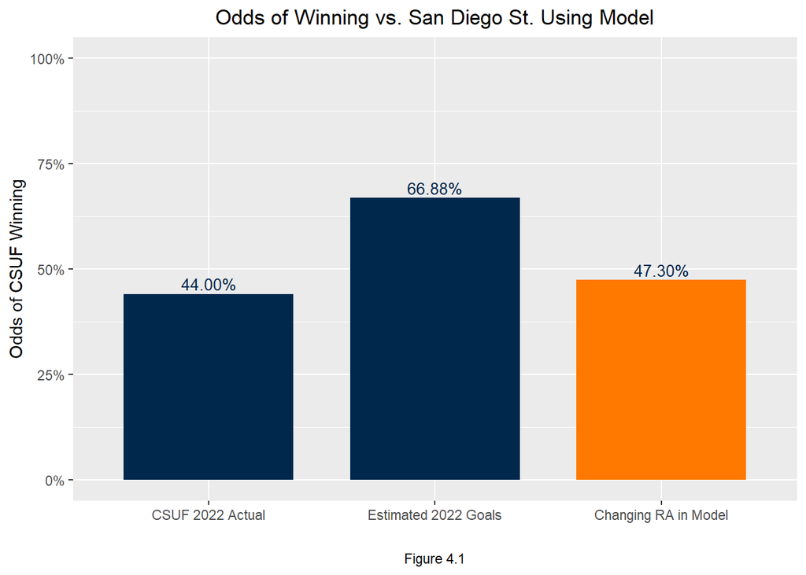

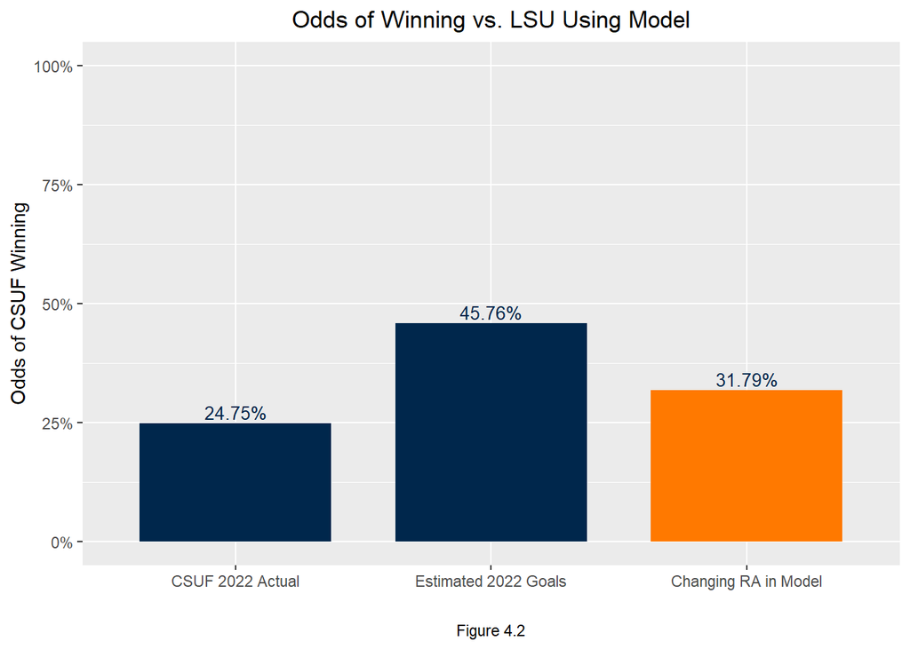

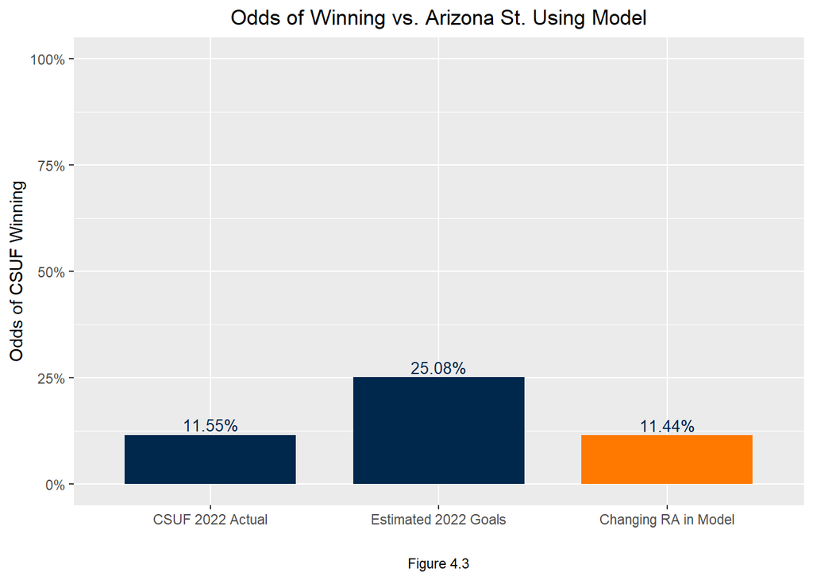

By changing the number of runs CSUF allows by 1 less run, we can see how that would effect the likelihood of CSUF winning each of these games, keeping the other statistics constant. Using the model in this way can provide immediate feedback on goals for next season and gives the ability to set goals that are attainable for the team.